# Lab 1 Assignment - Review/Introduction to R and Data Structures

SOC 325: Quantified-Self

2023-01-27

Write all code in the chunks provided. Complete this `.Rmd` file and knit it into an `.html`. You must upload both files for credit.

Remember to unzip to a real directory before running everything!

# 1. Basics of R and R markdown

## 1.1. Create a vector containing elements 10, 22, 27, 19, 20 and assign it with a name.

```r
vec=c(10,22,27,19,20)
```

## 1.2. Use R as a calculator to compute the following values.

1. 27(38-17)
2. ln(14^7)
3. sqrt(436/12)

```r
27*(38-17)
```

```
## [1] 567
```

```r
log(14^7)
```

```
## [1] 18.4734
```

```r
sqrt(436/12)
```

```
## [1] 6.027714
```

## 1.3. Run the below code to create a vector. Observe what e contains and use `?seq` to see help of function `seq()`.

```r
e <- seq(0, 10, length=5)
e
```

```
## [1]  0.0  2.5  5.0  7.5 10.0
```

Create the following vectors: b = (87, 86, 85, …, 56)

```r
b=seq(87,56,-1)
```

What is the 19th, 20th, and 21st elements of b?

```r
b[c(19,20,21)]
```

```
## [1] 69 68 67
```

## 1.4. Compute the following statistics of b:

1. sum
2. median
3. standard deviation

```r
sum(b)
```

```
## [1] 2288
```

```r
median(b)
```

```
## [1] 71.5
```

```r
sd(b)
```

```
## [1] 9.380832
```

# 2. Research Question (You don’t need code for this question)

*For this problem you’ll answer some questions to help explore your interests in data science. These are questions that you’re interested in. They don’t have to be things that you know the answer to and still less new areas of study.*

*However, problem 3 asks you to come up with a ‘big data’ dataset that you think you might use to answer your question. If you’re new to R or not sure about what to do, I encourage you to use the Airbnb data that we’ll be using in class. In that case, make sure that your answers to problem 2 relate to the airbnb data.*

## 2.1: What are some areas of interest for you within sociology, big data, and computational social science?

## 2.2: Provide a link to a dataset which you think intersects with one of your interests. Explain the connection. You can find datasets by doing a google search or by looking here:http://hadoopilluminated.com/hadoop_illuminated/Public_Bigdata_Sets.html or here: https://www.kaggle.com/

If you’re using the airbnb set, explain how it connects to your interests.

# 3. Import data and identify variables

## 3.1. Import your data into R and output the column names.

```r
library(tidyverse)
library(here)
airbnb<-read_csv(here("data","seattle_airbnb.csv"))
glimpse(airbnb)
```

```
## Rows: 100
## Columns: 6
## $ id                  <dbl> 2318, 4291, 5682, 6606, 9419, 9460, 9531, 9534, 95…
## $ name                <chr> "Casa Madrona - Urban Oasis, 1 block from the Park…
## $ neighbourhood_group <chr> "Central Area", "Other neighborhoods", "Delridge",…
## $ neighbourhood       <chr> "Madrona", "Roosevelt", "South Delridge", "Walling…
## $ price               <dbl> 296, 82, 48, 90, 70, 80, 165, 125, 120, 125, 48, 6…
## $ number_of_reviews   <dbl> 16, 54, 428, 110, 120, 366, 34, 32, 61, 48, 35, 89…
```

## 3.2. Use View(), head() or tail() to check your data. What variables does it contain? How many rows are in your data? What is the unit of analysis in your data?

```r
#View(airbnb)
head(airbnb)
```

```
## # A tibble: 6 × 6
##      id name                                       neigh…¹ neigh…² price numbe…³
##   <dbl> <chr>                                      <chr>   <chr>   <dbl>   <dbl>
## 1  2318 Casa Madrona - Urban Oasis, 1 block from … Centra… Madrona   296      16
## 2  4291 Sunrise in Seattle Master Suite            Other … Roosev…    82      54
## 3  5682 Cozy Studio, min. to downtown -WiFi        Delrid… South …    48     428
## 4  6606 Fab, private seattle urban cottage!        Other … Wallin…    90     110
## 5  9419 Glorious sun room w/ memory foambed        Other … George…    70     120
## 6  9460 Downtown/Convention Ctr B&B - Nice!        Downto… First …    80     366
## # … with abbreviated variable names ¹neighbourhood_group, ²neighbourhood,
## #   ³number_of_reviews
```

```r
tail(airbnb)
```

```
## # A tibble: 6 × 6
##       id name                                      neigh…¹ neigh…² price numbe…³
##    <dbl> <chr>                                     <chr>   <chr>   <dbl>   <dbl>
## 1 222885 Gluten Free on Phinney Ridge              Other … Phinne…    75      28
## 2 224763 Location! Sleeps 4 WiFi  Luxurious, Park… Downto… Bellto…   149      72
## 3 225820 Family Friendly on Phinney Ridge          Other … Phinne…    90      69
## 4 226495 Fun apartment in Ballard, Seattle         Ballard Whitti…   170      72
## 5 226536 Serene Room in Sunny Cottage near Discov… Magnol… Lawton…    46     116
## 6 226677 Sunny Parisian beauty room w/ comfy bed   Other … George…    55     101
## # … with abbreviated variable names ¹neighbourhood_group, ²neighbourhood,
## #   ³number_of_reviews
```

## 3.3. Discuss how might some variables serve your research interest as discussed in problem 2 above.

# Problem 4: Piping Hot Variables

*This problem uses `dplyr` verbs to answer questions about an Airbnb data set.*

## 4.1: Get the data

Go to [Inside Airbnb](http://insideairbnb.com/get-the-data.html) and download the “Detailed Listings” data for Seattle, `listings.csv.gz`. This file has many more variables than the “Summary” file we’ve been using in class. Put it in a `data/` subfolder in your `hw-02` project folder.

[This is a compressed (gzipped) file, but R should be able to handle it as-is. If you run into trouble, try unzipping the file before reading it into R.]

## 4.2: Set up your R environment

1. Load the tidyverse
2. Read the detailed Airbnb data into R

```r
## See above
airbnb<-read_csv("http://data.insideairbnb.com/united-states/wa/seattle/2022-12-24/data/listings.csv.gz")
glimpse(airbnb)
```

```
## Rows: 6,166
## Columns: 75
## $ id                                           <dbl> 844939, 6606, 9596, 84676…
## $ listing_url                                  <chr> "https://www.airbnb.com/r…
## $ scrape_id                                    <dbl> 2.022122e+13, 2.022122e+1…
## $ last_scraped                                 <date> 2022-12-24, 2022-12-24, …
## $ source                                       <chr> "city scrape", "city scra…
## $ name                                         <chr> "Five Star Downtown Desig…
## $ description                                  <chr> "Next to the Space Needle…
## $ neighborhood_overview                        <chr> "The condo is in award-wi…
## $ picture_url                                  <chr> "https://a0.muscache.com/…
## $ host_id                                      <dbl> 4411144, 14942, 14942, 44…
## $ host_url                                     <chr> "https://www.airbnb.com/u…
## $ host_name                                    <chr> "Emma", "Joyce", "Joyce",…
## $ host_since                                   <date> 2012-12-15, 2009-04-26, …
```

[output cut: 62 more lines]

## 4.3: Use the data to answer a question

*For how many units does the host live in a different neighborhood from the listing? For how many units does the host live in the same neighborhood as the listing?*

Try to figure out which variables to use from their names, and think about which verbs you’ve learned about might work to answer this question. See the hints at the end if you need help.

```r
## Number where Host lives (==) in Rental Neighborhood
airbnb%>%filter(host_neighbourhood==neighbourhood_cleansed)%>%count()
```

```
## # A tibble: 1 × 1
##       n
##   <int>
## 1  2132
```

```r
## Number where Host Does not (!=) lives in Rental Neighborhood
airbnb%>%filter(host_neighbourhood!=neighbourhood_cleansed)%>%count()
```

```
## # A tibble: 1 × 1
##       n
##   <int>
## 1  3675
```

## 4.4: Build on your answer

*Building on that work, what is the average number of listings for hosts that live in the same neighborhood as their listing? What’s the average for hosts who live in different neighborhoods from their listing?*

The `mean` function will take the average of a variable, but you might need to look up how to use it. See the hints for more suggestions if you get stuck.

```r
airbnb%>%group_by(room_type)%>%summarise(n=n()/nrow(airbnb))
```

```
## # A tibble: 4 × 2
##   room_type              n
##   <chr>              <dbl>
## 1 Entire home/apt 0.847
## 2 Hotel room      0.000324
## 3 Private room    0.150
## 4 Shared room     0.00195
```

## 4.5: Reflect and interpret

Reflect on your answer to 1.4. What might cause the results you got? How does that connect to the idea that Airbnb might be changing neighborhoods?

*Your answer should be at least a few sentences here*

# 5. Prepare and Visualize data

## 5.1. Set up your environment

Set up your environment by:

Reading the Airbnb data: There’s another new data set in the `data/` folder. This one has almost 10,000 cases and the census data by zipcode. These data are from New York City, not Seattle! (`nyc_airbnb_census_data.csv`)

```r
nyc<-read_csv(here("data","nyc_airbnb_census_data.csv"))
glimpse(nyc)
```

```
## Rows: 10,000
## Columns: 37
## $ id                             <dbl> 4.726700e+07, 5.268712e+07, 1.578132e+0…
## $ name                           <chr> "Clean & Cozy Apartment", "Homey 1-Bedr…
## $ host_id                        <dbl> 41658748, 32538641, 61842904, 90867640,…
## $ host_name                      <chr> "Ben", "Yim", "Catherine", "Darlene", "…
## $ neighbourhood_group            <chr> "Manhattan", "Manhattan", "Brooklyn", "…
## $ neighbourhood                  <chr> "Stuyvesant Town", "Hell's Kitchen", "C…
## $ latitude                       <dbl> 40.73558, 40.76055, 40.67893, 40.69320,…
## $ longitude                      <dbl> -73.97909, -73.99274, -73.96362, -73.76…
## $ room_type                      <chr> "Entire home/apt", "Entire home/apt", "…
## $ price                          <dbl> 225, 278, 120, 110, 151, 119, 240, 70, …
## $ minimum_nights                 <dbl> 30, 5, 30, 1, 2, 5, 30, 1, 30, 2, 30, 1…
## $ number_of_reviews              <dbl> 7, 5, 7, 9, 4, 19, 6, 59, 1, 19, 7, 23,…
## $ last_review                    <date> 2022-07-30, 2022-06-18, 2019-08-10, 20…
```

[output cut: 24 more lines]

We’ve given you absolute populations and proportions for the racial composition of the zipcode for each listing. We’ve also made a variable called ‘modal_race’ which is the race with the largest proportion in that neighborhood.

These variables are all in the last columns of the data set—you can try selecting them and using `summary()` to get a sense for what they contain.

## 5.2: Turn `price` into a number

There are a few ways to do this using `tidyverse` functions. See the hints below for some suggestions.

```r
nyc<-nyc%>%mutate(
  price=as.numeric(price)
)
```

## 5.3: Make a scatterplot

Use a scatter plot to compare how unit prices change with the proportion of a particular race.

Bonus: try grouping by zipcode (in any fashion) for this plot

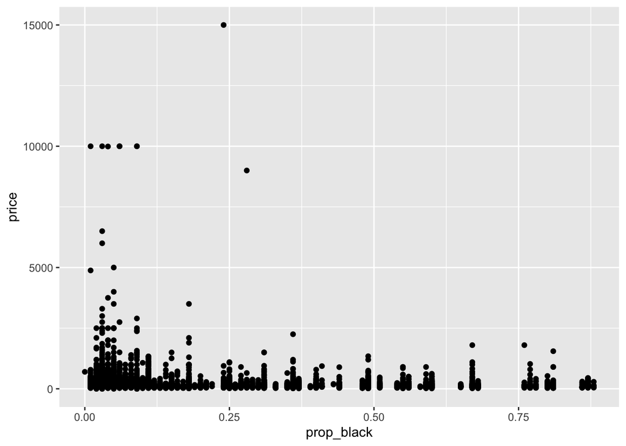

```r
nyc%>%ggplot(aes(y=price,x=prop_black))+geom_point()
```

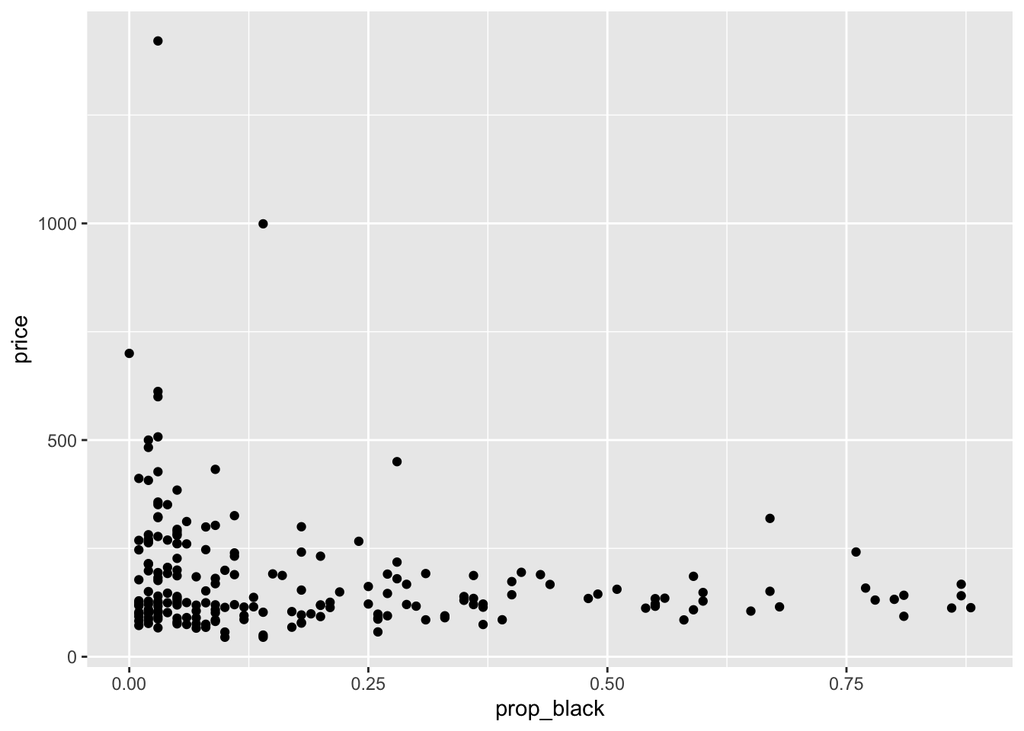

```r
nyc%>%group_by(zip)%>%summarise(price=mean(price),prop_black=mean(prop_black))%>%ggplot(aes(y=price,x=prop_black))+geom_point()
```

## 5.4: Make a boxplot

Use the `modal_race` variable to plot a boxplot comparing race and price. You may have to look up how to make a boxplot in `ggplot2`—what geom do you need?

Bonus: try showing how this comparison differs by neighborhood group.

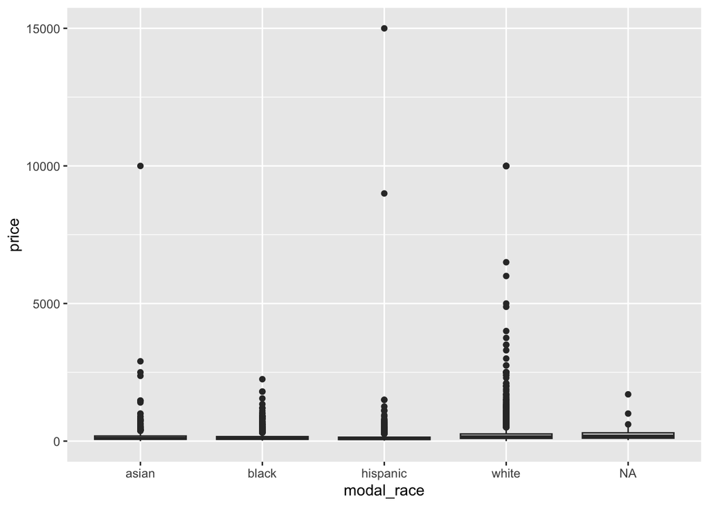

```r
nyc%>%ggplot(aes(y=price,x=modal_race))+geom_boxplot()
```

## 5.5: Interpret your answer

Interpret your answer to 5.4. Check the hints if you need help.

*Your answer should be at least a few sentences here*

## Bonus: how did we make the data?

There’s another file in the data folder, census.csv. Read it into R and have a look at it.

Download the full listings for New York City from Inside Airbnb, and see if you can join the Census data to it by zipcode using `left_join`. You’ll have to filter out some weird values for zipcode before you can merge.

```r
library(zipcodeR)
census<-read_csv(here("data","census.csv"))
## http://insideairbnb.com/get-the-data/
#nyc_dec<-read_csv("http://data.insideairbnb.com/united-states/ny/new-york-city/2022-12-04/data/listings.csv.gz")

################
## Small example
################

nyc_dec2<-read_csv("http://data.insideairbnb.com/united-states/ny/new-york-city/2022-12-04/visualisations/listings.csv")

## Get zipcodes using zipcodeR package
nyc_dec2_smp<-nyc_dec2[sample(1:NROW(nyc_dec2),20,replace=FALSE),]
zip<-lapply(1:length(nyc_dec2_smp$latitude),function(x){try(search_radius(lat=nyc_dec2_smp$latitude[x],lng=nyc_dec2_smp$longitude[x]))})
zip2<-sapply(zip,function(x){
 x$zipcode[which.min(x$distance)]
})

## Have to make zipcode numeric to make it comparables
nyc_dec2_smp<-nyc_dec2_smp%>%mutate(zipcode=as.numeric(zip2))
nyc_dec2_smp_census<-left_join(nyc_dec2_smp,census,by="zipcode")
glimpse(nyc_dec2_smp_census)
```

```
## Rows: 20
## Columns: 27
## $ id                             <dbl> 1.473871e+07, 2.366005e+07, 5.141125e+0…
## $ name                           <chr> "Clean + Spacious 2BR | Desk Space + Wi…
## $ host_id                        <dbl> 30283594, 173362161, 158969505, 3745961…
## $ host_name                      <chr> "Global Luxury Suites", "Elizabeth", "U…
## $ neighbourhood_group            <chr> "Manhattan", "Brooklyn", "Manhattan", "…
## $ neighbourhood                  <chr> "Hell's Kitchen", "Flatbush", "Lower Ea…
## $ latitude                       <dbl> 40.76153, 40.64435, 40.72112, 40.72930,…
## $ longitude                      <dbl> -73.99878, -73.96878, -73.99289, -73.98…
## $ room_type                      <chr> "Entire home/apt", "Private room", "Ent…
## $ price                          <dbl> 649, 65, 326, 251, 300, 90, 99, 110, 31…
## $ minimum_nights                 <dbl> 30, 28, 2, 1, 30, 1, 30, 1, 1, 90, 30, …
## $ number_of_reviews              <dbl> 3, 183, 43, 8, 25, 5, 0, 9, 16, 0, 1, 0…
## $ last_review                    <date> 2018-11-15, 2022-11-16, 2022-11-14, 20…
## $ reviews_per_month              <dbl> 0.04, 3.18, 2.71, 4.07, 0.30, 0.69, NA,…
## $ calculated_host_listings_count <dbl> 53, 5, 200, 4, 1, 7, 1, 2, 61, 23, 1, 1…
## $ availability_365               <dbl> 5, 194, 172, 232, 0, 337, 0, 344, 0, 36…
## $ number_of_reviews_ltm          <dbl> 0, 39, 35, 8, 0, 5, 0, 9, 6, 0, 0, 0, 1…
## $ license                        <lgl> NA, NA, NA, NA, NA, NA, NA, NA, NA, NA,…
## $ zipcode                        <dbl> 10018, 11226, 10002, 10009, 10162, 1135…
## $ white                          <dbl> 2480, 6005, 16330, 30587, 1442, 15546, …
## $ black                          <dbl> 334, 72591, 5257, 4775, 17, 341, 17, 28…
## $ asian                          <dbl> 1338, 2930, 37739, 8277, 96, 14975, 96,…
## $ latinx                         <dbl> 945, 17409, 20619, 15977, 91, 6028, 91,…
## $ full_pop                       <dbl> 5229, 101572, 81410, 61347, 1685, 37546…
## $ white_proportion               <dbl> 0.47427806, 0.05912062, 0.20058961, 0.4…
## $ black_proportion               <dbl> 0.063874546, 0.714675304, 0.064574377, …
## $ modal_race                     <chr> "white", "black", "asian", "white", "wh…
```

# 6. Your own data

## 6.1. Looking at the datasets used so far, think about a research question you’d like to investigate (try search about existing studies around your question). What variables do you plan to use to answer your question?

## 6.2. What is one way that you have to modify or examine your data to begin to answer your question?

## 6.3. Using the functions we’ve worked with in class (select, filter, arrange, mutate), plus any others you’d like to use, clean and transform your data set to make it ready for further exploration.

You must:

1. Create a new dataset that only includes the variables you’re interested in
2. Output a version of that dataset that only includes certain values of observations, hopefully ones you’re interested in.
3. Order your data by the values of one variable you’re interested in.
4. Create a modified version of one of your variables (many of you will *need* to do this, but even if you don’t, I want to see that you can)
5. Look up and try out one new verb for data transformation. The RStudio data transformation cheat sheet is a fantastic place to start: https://github.com/rstudio/cheatsheets/raw/master/data-transformation.pdf

For e., we’d recommend using `group_by` + `summarize`. You can group your data by one variable, and then see the mean (or similar) of another variable within each of those groups.

*Use as many code blocks as you need for a-e*

```r
nyc<-read_csv(here("data","nyc_airbnb_census_data.csv"))

## Select variables
nyc_sub<-nyc%>%select(
  room_type,
  price,
  number_of_reviews,
  neighbourhood,
  zip,
  city,
  prop_white,
  prop_black,
  modal_race
)

## Filter by price
nyc_sub_price<-nyc_sub%>%filter(price>mean(price))

## Check it
nyc_sub%>%dim()
```

```
## [1] 10000     9
```

```r
nyc_sub_price%>%dim()
```

```
## [1] 2912    9
```

```r
## order by price
nyc_sub_price<-nyc_sub_price%>%arrange(desc(price))
nyc_sub_price
```

```
## # A tibble: 2,912 × 9
##    room_type       price number_of…¹ neigh…²   zip city  prop_…³ prop_…⁴ modal…⁵
##    <chr>           <dbl>       <dbl> <chr>   <dbl> <chr>   <dbl>   <dbl> <chr>
##  1 Entire home/apt 15000           0 East H… 10029 New …    0.18    0.24 hispan…
##  2 Entire home/apt 10000           0 Upper … 10023 New …    0.76    0.03 white
##  3 Private room    10000           0 Lower … 10002 New …    0.25    0.09 asian
##  4 Shared room     10000          11 Murray… 10016 New …    0.63    0.06 white
##  5 Entire home/apt 10000          28 Long I… 11106 Quee…    0.47    0.06 white
##  6 Entire home/apt  9999           1 Upper … 10075 New …    0.83    0.01 white
##  7 Private room     9999           0 Midtown 10018 New …    0.51    0.09 white
##  8 Private room     9990           9 East V… 10003 New …    0.72    0.04 white
##  9 Private room     9000           0 Briarw… 11435 Bria…    0.11    0.28 hispan…
## 10 Entire home/apt  6500           0 Tribeca 10007 New …    0.72    0.03 white
## # … with 2,902 more rows, and abbreviated variable names ¹number_of_reviews,
## #   ²neighbourhood, ³prop_white, ⁴prop_black, ⁵modal_race
```

```r
## modified price high/low
nyc_sub_price<-nyc_sub_price%>%mutate(
  price_hilo=ifelse(price>1000,"high","low")
)
glimpse(nyc_sub_price)
```

```
## Rows: 2,912
## Columns: 10
## $ room_type         <chr> "Entire home/apt", "Entire home/apt", "Private room"…
## $ price             <dbl> 15000, 10000, 10000, 10000, 10000, 9999, 9999, 9990,…
## $ number_of_reviews <dbl> 0, 0, 0, 11, 28, 1, 0, 9, 0, 0, 17, 0, 2, 0, 0, 0, 0…
## $ neighbourhood     <chr> "East Harlem", "Upper West Side", "Lower East Side",…
## $ zip               <dbl> 10029, 10023, 10002, 10016, 11106, 10075, 10018, 100…
## $ city              <chr> "New York", "New York", "New York", "New York", "Que…
## $ prop_white        <dbl> 0.18, 0.76, 0.25, 0.63, 0.47, 0.83, 0.51, 0.72, 0.11…
## $ prop_black        <dbl> 0.24, 0.03, 0.09, 0.06, 0.06, 0.01, 0.09, 0.04, 0.28…
## $ modal_race        <chr> "hispanic", "white", "asian", "white", "white", "whi…
## $ price_hilo        <chr> "high", "high", "high", "high", "high", "high", "hig…
```

```r
## e
nyc_sub_price%>%group_by(price_hilo)%>%summarise(n=n(),
                                                 mean_price=mean(price)
                                                 )
```

```
## # A tibble: 2 × 3
##   price_hilo     n mean_price
##   <chr>      <int>      <dbl>
## 1 high         116      2515.
## 2 low         2796       342.
```

# Hints

4.3 Try using these steps:

- Step 1: identify the variables you need
  - Listing neighborhood: `neighbourhood`
  - Host’s neighborhood: `host_neighbourhood`
- Step 2: Filter the data to only include the rows where those variables are not equal. Look back to Module 2 (or look online) if you need a reminder about how to write “equal”, “not equal”, and so on in R.
- Step 3: How many rows are left in the filtered data?

Extra food for thought: how do “NA” (missing) values get handled here? Do you think that makes sense? Should you do something else with them, maybe using `is.na`?

4.4 The variable for number of listings is `host_listings_count`. You might want to make a new variable indicating if a host is a local host (your answer to 1.3 will help here!). There are many ways to use `mean` on a subset of data, but the best approach is one we introduce in Module 5: `group_by` + `summarize`. Try it out now if you can! For this problem, don’t worry about NAs.

5.2

Use `mutate` for this. You can replace the original `price` variable, or name it something else. There are a couple things you can use on `price` inside the mutate:

- `parse_number`, a function in the `readr` package, does a good job of converting currency to numbers on its own.
- `str_extract` with `pattern = "\\d+"`, then `as.numeric`, will extract numbers from a string, then convert the new (sub)string to a number.
- `str_remove_all`, with `pattern = "[\\$|,]"`, then `as.numeric`, will remove all dollar signs and commas.

5.5

Check out these resources if you’re not sure about interpreting box plots:

https://magoosh.com/statistics/reading-interpreting-box-plots/

https://www.youtube.com/watch?v=oBREri10ZHk

6.3

1. use select()
2. use filter()
3. use arrange()
4. use mutate()
5. use group_by(var1) %>% summarise(mean = mean(var2))

Write all code in the chunks provided!

Remember to unzip to a real directory before running everything!

Problems should be roughly analogous to what we’ve done in class, with a few extensions. There are hints at the bottom of this document if you get stuck. If you still can’t figure it out, go to google/stack exchange/ask a friend. Finally, email your TA or come to office hours :).

# Problem 7: Google Trends

## 7.1

*Go to Google Trends and search for “covid-19 vaccine”. Look at variations by time and by region in US. What do you observe?*

# Problem 7: Join data frames

In this problem we will use data in the `nycflightdata13` package to perform joining of data frames.

It includes five dataframes, some of which contain missing data (`NA`).

- `flights`: flights leaving JFK, LGA or EWR in 2013
- `airlines`: airline abbreviations
- `airports`: airport metadata
- `planes`: airplane metadata
- `weather`: hourly weather data from JFK, LGA and EWR

Note these are **separate data frames**, each needing to be loaded separately using `data()`.

## 7.1. Set up your environment:

1. Install and load the `nycflights13` package. Load the `tidyverse` package.
2. Load data sets `flights`, `planes`, `airlines`

```r
#install.packages("nycflights13")
library(nycflights13)
library(tidyverse)

## Load data
data(list=c("flights","planes","airlines"))
```

## 7.2 Find data frames

*We’ll be looking at who manufactures the planes that flew to Seattle. Which are the two data frames we need to join?*

## 7.3. Find common keys

*Take a look at variables contained the two data frames. Which variable(s) should be used as the key to join?*

## 7.4. Join the two data frames

```r
fl_man<-left_join(flights,planes,by="tailnum")
```

## 7.5. Build on your answer

*For flights with a destination of Seattle, who are the largest manufacturers? Give top five of the manufacturers.* (Check hints if you have troubles)

```r
fl_man%>%filter(dest=="SEA")%>%group_by(manufacturer)%>% summarise(n=n())%>%arrange(desc(n))
```

```
## # A tibble: 6 × 2
##   manufacturer           n
##   <chr>              <int>
## 1 BOEING              2659
## 2 AIRBUS               475
## 3 AIRBUS INDUSTRIE     394
## 4 <NA>                 391
## 5 BARKER JACK L          2
## 6 CIRRUS DESIGN CORP     2
```

```r
## Drop NA

fl_man%>%filter(dest=="SEA")%>%group_by(manufacturer)%>% summarise(n=n())%>%na.omit()%>%arrange(desc(n))
```

```
## # A tibble: 5 × 2
##   manufacturer           n
##   <chr>              <int>
## 1 BOEING              2659
## 2 AIRBUS               475
## 3 AIRBUS INDUSTRIE     394
## 4 BARKER JACK L          2
## 5 CIRRUS DESIGN CORP     2
```

## 7.6. Use the data to anwer the below questions

*We’d like to know which airlines had the most flights to Seattle from NYC. Which are the two data frames we need to join, and on which key variable(s)?*

```r
fl_airline<-left_join(flights,airlines,by="carrier")
fl_airline%>%filter(dest=="SEA"&origin%in%c("JFK","LGA"))%>%group_by(name)%>%summarise(n=n())
```

```
## # A tibble: 3 × 2
##   name                       n
##   <chr>                  <int>
## 1 American Airlines Inc.   365
## 2 Delta Air Lines Inc.    1213
## 3 JetBlue Airways          514
```

## 7.7.

*Join the two data frames in 7.6 and list the top five airlines.*

```r
## See above
```

# Problem 8: Your research question

Think about the research question you have in mind. Plot is a great way to understand patterns, key relationships and uncertainties in a data set. Here we’ll ask you to plan about plotting your variables of interest for your research question. Try to think about **3 plots** below:

*For each of the 3 plots, provide:*

A. The purpose of the plot: what do you want people to understand when they see this?

B. The type of plot: what geom functions will you use to present the plot? Why are those the best choices?

C. Limitations/biases: What is missing from this presentation? Could someone get the wrong idea? What can you do to help limit the negative possibilities here?

### Plot idea 1

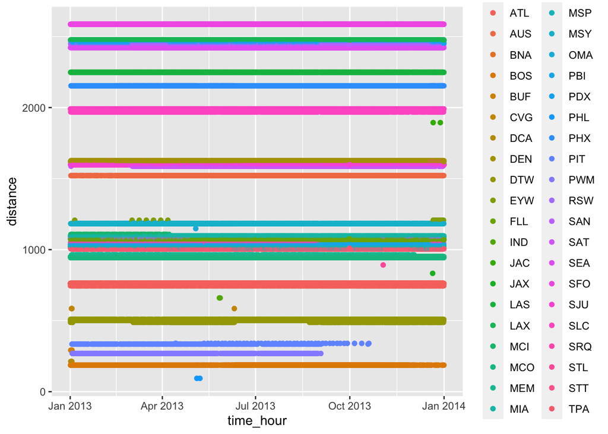

```r
fl_airline%>%filter(carrier=="DL")%>%
  ggplot(aes(y=distance,x=time_hour,color=dest))+
  geom_point()
```

### Plot idea 2

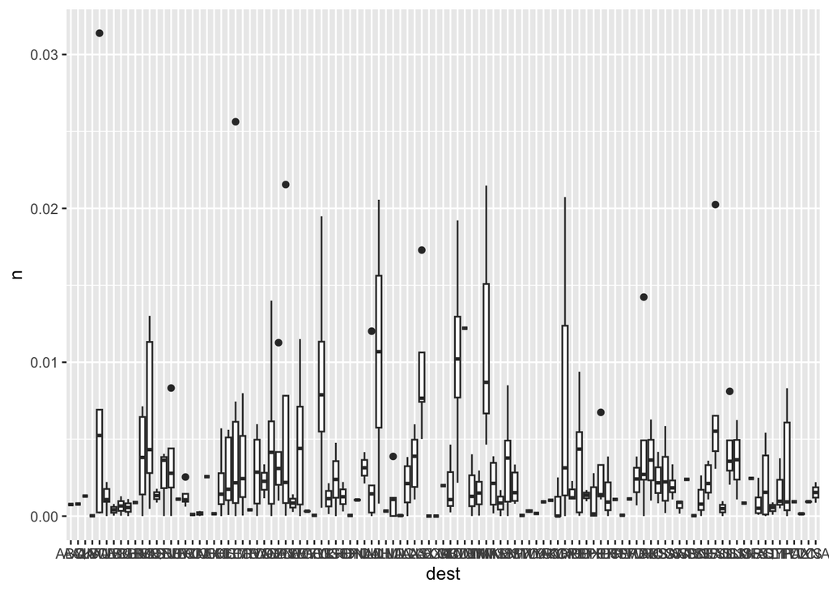

```r
fl_airline%>%group_by(carrier,dest)%>%
              summarise(n=n()/NROW(.),
              vgdist=mean(distance))%>%
  ggplot(aes(y=n,x=dest))+
  geom_boxplot()
```

### Plot idea 3

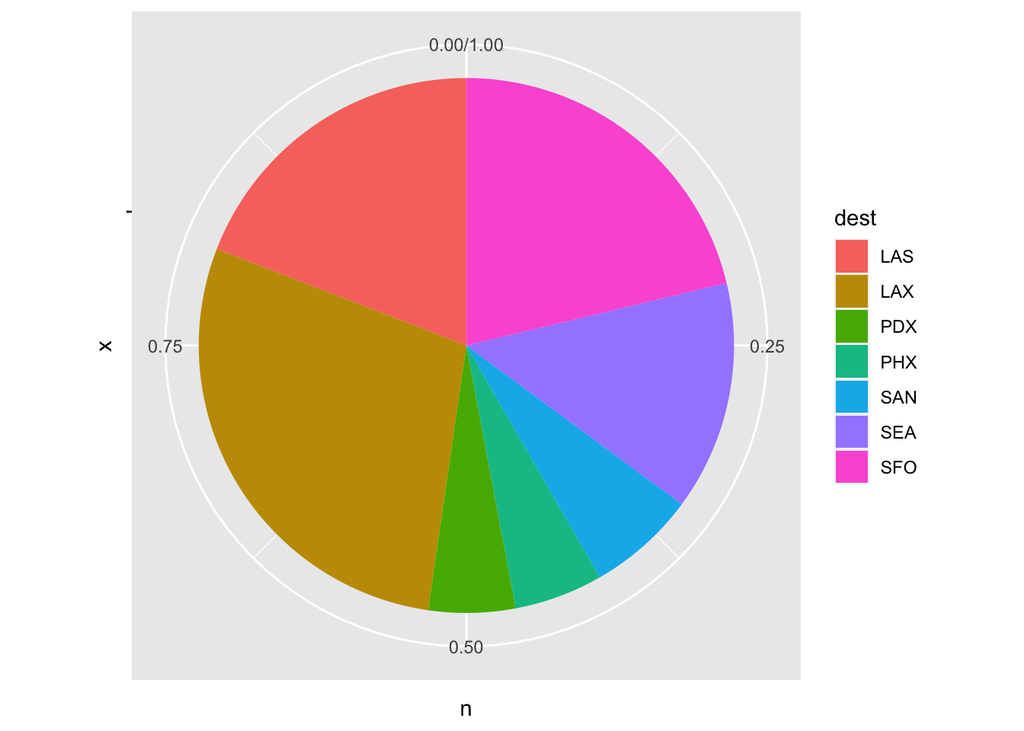

```r
fl_airline%>%filter(carrier=="DL"&distance>2*mean(distance))%>%group_by(dest)%>%summarise(n=n()/NROW(.),avgdist=mean(distance))%>%
  ggplot(aes(x="",y=n,fill=dest))+
  geom_bar(width = 1, stat = "identity")+
  coord_polar("y", start=0)
```

Hint

7.5

use `left_join()` by “tailnum” to join the two data frames, then count() observations by manufacturer, and then use arrange() with descending order.